# Lab 5A - Machine Learning in Practice

### 1. Load the Data

1. Load all required libraries.

```python
import os
import pandas as pd
import seaborn as sns
import numpy as np
import matplotlib.pyplot as plt
from sklearn.preprocessing import StandardScaler
from sklearn.model_selection import train_test_split
from sklearn.model_selection import GridSearchCV
from sklearn.neighbors import KNeighborsClassifier
from sklearn.tree import DecisionTreeClassifier
from sklearn.neural_network import MLPClassifier
from sklearn.metrics import accuracy_score
```

2. Set the working directory to "C:\Workshop\Data".

```python
os.chdir("C:\Workshop\Data")
```

3. Read the Titanic CSV file into a data frame called *titanic*.

```python
titanic = pd.read_csv("Titanic.csv")
```

### 2. Explore the Data

1. Inspect the data using the `head` function.

```python
titanic.head()
```

|  | pclass | survived | name | sex | age | sibsp | parch | ticket | fare | cabin | embarked | boat | body | home.dest |
| --- | --- | --- | --- | --- | --- | --- | --- | --- | --- | --- | --- | --- | --- | --- |
| 0 | 1 | 1 | Allen, Miss. Elisabeth Walton | female | 29.0000 | 0 | 0 | 24160 | 211.3375 | B5 | S | 2 | NaN | St Louis, MO |
| 1 | 1 | 1 | Allison, Master. Hudson Trevor | male | 0.9167 | 1 | 2 | 113781 | 151.5500 | C22 C26 | S | 11 | NaN | Montreal, PQ / Chesterville, ON |
| 2 | 1 | 0 | Allison, Miss. Helen Loraine | female | 2.0000 | 1 | 2 | 113781 | 151.5500 | C22 C26 | S | NaN | NaN | Montreal, PQ / Chesterville, ON |
| 3 | 1 | 0 | Allison, Mr. Hudson Joshua Creighton | male | 30.0000 | 1 | 2 | 113781 | 151.5500 | C22 C26 | S | NaN | 135.0 | Montreal, PQ / Chesterville, ON |
| 4 | 1 | 0 | Allison, Mrs. Hudson J C (Bessie Waldo Daniels) | female | 25.0000 | 1 | 2 | 113781 | 151.5500 | C22 C26 | S | NaN | NaN | Montreal, PQ / Chesterville, ON |

2. Summarize the columns in the data frame using the `info` function.

```python
titanic.info()
```

```
<class 'pandas.core.frame.DataFrame'>
RangeIndex: 1309 entries, 0 to 1308
Data columns (total 14 columns):
pclass       1309 non-null int64
survived     1309 non-null int64
name         1309 non-null object
sex          1309 non-null object
age          1046 non-null float64
sibsp        1309 non-null int64
parch        1309 non-null int64
ticket       1309 non-null object
fare         1308 non-null float64
cabin        295 non-null object
embarked     1307 non-null object
boat         486 non-null object
body         121 non-null float64
home.dest    745 non-null object
dtypes: float64(3), int64(4), object(7)
memory usage: 143.2+ KB
```

3. Sumarize the data in the data frame using the `describe` function.

```python
titanic.describe(
    include = "all")
```

|  | pclass | survived | name | sex | age | sibsp | parch | ticket | fare | cabin | embarked | boat | body | home.dest |
| --- | --- | --- | --- | --- | --- | --- | --- | --- | --- | --- | --- | --- | --- | --- |
| count | 1309.000000 | 1309.000000 | 1309 | 1309 | 1046.000000 | 1309.000000 | 1309.000000 | 1309 | 1308.000000 | 295 | 1307 | 486 | 121.000000 | 745 |
| unique | NaN | NaN | 1307 | 2 | NaN | NaN | NaN | 929 | NaN | 186 | 3 | 27 | NaN | 369 |
| top | NaN | NaN | Connolly, Miss. Kate | male | NaN | NaN | NaN | CA. 2343 | NaN | C23 C25 C27 | S | 13 | NaN | New York, NY |
| freq | NaN | NaN | 2 | 843 | NaN | NaN | NaN | 11 | NaN | 6 | 914 | 39 | NaN | 64 |
| mean | 2.294882 | 0.381971 | NaN | NaN | 29.881135 | 0.498854 | 0.385027 | NaN | 33.295479 | NaN | NaN | NaN | 160.809917 | NaN |
| std | 0.837836 | 0.486055 | NaN | NaN | 14.413500 | 1.041658 | 0.865560 | NaN | 51.758668 | NaN | NaN | NaN | 97.696922 | NaN |
| min | 1.000000 | 0.000000 | NaN | NaN | 0.166700 | 0.000000 | 0.000000 | NaN | 0.000000 | NaN | NaN | NaN | 1.000000 | NaN |
| 25% | 2.000000 | 0.000000 | NaN | NaN | 21.000000 | 0.000000 | 0.000000 | NaN | 7.895800 | NaN | NaN | NaN | 72.000000 | NaN |
| 50% | 3.000000 | 0.000000 | NaN | NaN | 28.000000 | 0.000000 | 0.000000 | NaN | 14.454200 | NaN | NaN | NaN | 155.000000 | NaN |
| 75% | 3.000000 | 1.000000 | NaN | NaN | 39.000000 | 1.000000 | 0.000000 | NaN | 31.275000 | NaN | NaN | NaN | 256.000000 | NaN |
| max | 3.000000 | 1.000000 | NaN | NaN | 80.000000 | 8.000000 | 9.000000 | NaN | 512.329200 | NaN | NaN | NaN | 328.000000 | NaN |

4. Create a correlation matrix using the `corr` function.

```python
correlations = titanic.corr()
```

5. Create a correlogram using the seaborn `heatmap` function.

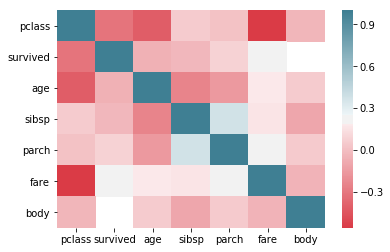

```python
sns.heatmap(
    data = correlations,
    cmap = sns.diverging_palette(
        h_neg = 10,
        h_pos = 220,
        as_cmap = True));
```

6. Inspect missing values with the `isnull` and `sum` functions.

```python
titanic.isnull().sum()
```

```
pclass          0
survived        0
name            0
sex             0
age           263
sibsp           0
parch           0
ticket          0
fare            1
cabin        1014
embarked        2
boat          823
body         1188
home.dest     564
dtype: int64
```

### 3. Transform the Data

*Note: It may be helpful to inspect the result of each transformation using the `head` function.*

1. Assign the raw data to a temporary data frame.

```python
temp = titanic
```

2. Encode the categorical variable *sex* as one-hot dummy variables for female and male.

```python
dummies = pd.get_dummies(temp.sex)
temp = pd.concat([temp, dummies], axis = 1)
```

3. Imput missing values for Age using the mean age.

```python
meanAge = temp.age.mean()

temp.age = temp.age.fillna(meanAge)
```

4. Engineer a new feature named *family* as the total siblings, spouses, parents, and children.

```python
temp["family"] = temp.sibsp + temp.parch
```

5. Encode the integer *survived* variable as a categorical variable with levels "Yes" and "No".

```python
temp.survived.replace((1, 0), ('Yes', 'No'), inplace = True)
```

6. Select only the following features: pclass, male, female, age, family, and survived.

```python
temp = temp.loc[:, ["pclass", "male", "female", "age", "family", "survived"]]
```

7. Rename the selected columns: Class, Male, Female, Age, Family, and Survived.

```python
temp.columns = ["Class", "Male", "Female", "Age", "Family", "Survived"]
```

8. Inspect the transformed data with the `head` function.

```python
temp.head()
```

|  | Class | Male | Female | Age | Family | Survived |
| --- | --- | --- | --- | --- | --- | --- |
| 0 | 1 | 0 | 1 | 29.0000 | 0 | Yes |
| 1 | 1 | 1 | 0 | 0.9167 | 3 | Yes |
| 2 | 1 | 0 | 1 | 2.0000 | 3 | No |
| 3 | 1 | 1 | 0 | 30.0000 | 3 | No |
| 4 | 1 | 0 | 1 | 25.0000 | 3 | No |

9. Create a data frame of the features named *X*.

```python
X = temp.iloc[:, 0:5]
```

10. Create a new series for the labels named *y*.

```python
y = temp.Survived
```

11. Scale the feature data using the standard scaler.

```python
scaler = StandardScaler()

scaler.fit(X)

X_scaled = scaler.transform(X)
```

### 4. Create the Training and Test Set

1. Set the random number seed to 42

```python
np.random.seed(42)
```

2. Create stratified training and test sets (80/20).

```python
X_train, X_test, y_train, y_test = train_test_split(
    X,
    y,
    stratify = y,
    train_size = 0.80,
    test_size = 0.20)
```

### 5. Create KNN Classifier Models

1. Create a KNN model.

```python
knn_model = KNeighborsClassifier()
```

```python
knn_params = [5, 7, 9, 11, 13]

knn_param_grid = {"n_neighbors" : knn_params }
```

3. Create 10 KNN models for each of the five hyper-parameters using 10-fold cross validation.

```python
knn_models = GridSearchCV(
    estimator = knn_model,
    param_grid = knn_param_grid,
    scoring = "accuracy",
    cv = 10,
    verbose = 1)
```

4. Train all 50 models using the training set.

```python
knn_models.fit(
    X = X_train,
    y = y_train)
```

```
Fitting 10 folds for each of 5 candidates, totalling 50 fits
```

```
[Parallel(n_jobs=1)]: Done  50 out of  50 | elapsed:    3.0s finished
```

```
GridSearchCV(cv=10, error_score='raise',
       estimator=KNeighborsClassifier(algorithm='auto', leaf_size=30, metric='minkowski',
           metric_params=None, n_jobs=1, n_neighbors=5, p=2,
           weights='uniform'),
       fit_params=None, iid=True, n_jobs=1,
       param_grid={'n_neighbors': [5, 7, 9, 11, 13]},
       pre_dispatch='2*n_jobs', refit=True, return_train_score='warn',
       scoring='accuracy', verbose=1)
```

5. Get the average accuracy for each of the five hyperparameters.

```python
knn_avg_scores = knn_models.cv_results_["mean_test_score"]
```

6. Display the average accuracy for each hyper-parameter.

```python
for i in range(0, 5):
    print("{:>3} : {:0.3f}"
        .format(knn_params[i], knn_avg_scores[i]))
```

```
  5 : 0.756
  7 : 0.771
  9 : 0.780
 11 : 0.772
 13 : 0.761
```

7. Plot the change in accuracy over each hyper-parameter.

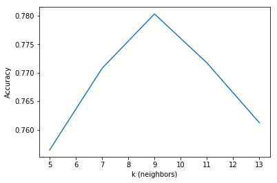

```python
plt.plot(
    knn_params,
    knn_avg_scores)
plt.xlabel("k (neighbors)")
plt.ylabel("Accuracy")
plt.show()
```

8. Get the hyper-parameter, average accuracy, and standard error of the top performing model.

```python
knn_top_index = np.argmax(knn_avg_scores)
knn_top_param = knn_params[knn_top_index]
knn_top_score = knn_avg_scores[knn_top_index]
knn_top_error = knn_models.cv_results_["std_test_score"][knn_top_index]
```

9. Inspect the top performing model.

```python
print("Top knn model is k = {:d} at {:0.2f} +/- {:0.3f} accuracy"
    .format(knn_top_param, knn_top_score, knn_top_error))
```

```
Top knn model is k = 9 at 0.78 +/- 0.030 accuracy
```

### 6. Create Decision Tree Classifier Models.

1. Create a decision tree model.

```python
tree_model = DecisionTreeClassifier()
```

2. Define the hyper-parameters to test (i.e. max_depth = {3, 4, 5, 6, 7}).

```python
tree_params = [3, 4, 5, 6, 7]

tree_param_grid = {"max_depth" : tree_params }
```

3. Create 10 tree models for each of the 5 hyper-parameters using 10-fold cross validation.

```python
tree_models = GridSearchCV(
    estimator = tree_model,
    param_grid = tree_param_grid,
    scoring = "accuracy",
    cv = 10,
    verbose = 1)
```

4. Train all 50 models using the training set.

```python
tree_models.fit(
    X = X_train,
    y = y_train)
```

```
Fitting 10 folds for each of 5 candidates, totalling 50 fits
```

```
[Parallel(n_jobs=1)]: Done  50 out of  50 | elapsed:    1.3s finished
```

```
GridSearchCV(cv=10, error_score='raise',
       estimator=DecisionTreeClassifier(class_weight=None, criterion='gini', max_depth=None,
            max_features=None, max_leaf_nodes=None,
            min_impurity_decrease=0.0, min_impurity_split=None,
            min_samples_leaf=1, min_samples_split=2,
            min_weight_fraction_leaf=0.0, presort=False, random_state=None,
            splitter='best'),
       fit_params=None, iid=True, n_jobs=1,
       param_grid={'max_depth': [3, 4, 5, 6, 7]}, pre_dispatch='2*n_jobs',
       refit=True, return_train_score='warn', scoring='accuracy',
       verbose=1)
```

5. Get the average accuracy for each hyper-parameter.

```python
tree_avg_scores = tree_models.cv_results_["mean_test_score"]
```

6. Display the average accuracy for each hyper-parameter.

```python
for i in range(0, 5):
    print("{:>3} : {:0.3f}"
        .format(tree_params[i], tree_avg_scores[i]))
```

```
  3 : 0.810
  4 : 0.810
  5 : 0.797
  6 : 0.784
  7 : 0.778
```

7. Plot the change in accuracy over each hyper-parameter.

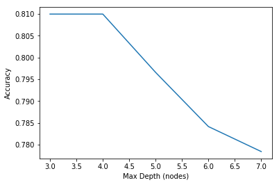

```python
plt.plot(
    tree_params,
    tree_avg_scores)
plt.xlabel("Max Depth (nodes)")
plt.ylabel("Accuracy")
plt.show()
```

8. Get the hyper-parameter, average accuracy, and standard error for the top-performing model.

```python
tree_top_index = np.argmax(tree_avg_scores)
tree_top_param = tree_params[tree_top_index]
tree_top_score = tree_avg_scores[tree_top_index]
tree_top_error = tree_models.cv_results_["std_test_score"][tree_top_index]
```

9. Inspect the top-performing model.

```python
print("Top tree model is k = {:d} at {:0.2f} +/- {:0.3} accuracy"
    .format(tree_top_param, tree_top_score, tree_top_error))
```

```
Top tree model is k = 3 at 0.81 +/- 0.03 accuracy
```

### 7. Create Neural Network Classifier Models.

1. Create a neural network model with tanh activation functions and 5000 max iterations.

```python
neural_model = MLPClassifier(
    activation = "tanh",
    max_iter = 5000)
```

2. Define hyper-parameters to test (i.e. hidden_layer_sizes = {3, 4, 5, 6, 7}).

```python
neural_params = [3, 4, 5, 6, 7]

neural_param_grid = {"hidden_layer_sizes" : neural_params }
```

3. Create 10 models for each of the 5 hyper-parameters using 10-fold cross validation.

```python
neural_models = GridSearchCV(
    estimator = neural_model,
    param_grid = neural_param_grid,
    scoring = "accuracy",
    cv = 10,
    verbose = 1)
```

4. Train all 50 models using the training set.  
*Note: This could take a few minutes.*

```python
neural_models.fit(
    X = X_train,
    y = y_train)
```

```
Fitting 10 folds for each of 5 candidates, totalling 50 fits
```

```
[Parallel(n_jobs=1)]: Done  50 out of  50 | elapsed:  2.0min finished
```

```
GridSearchCV(cv=10, error_score='raise',
       estimator=MLPClassifier(activation='tanh', alpha=0.0001, batch_size='auto', beta_1=0.9,
       beta_2=0.999, early_stopping=False, epsilon=1e-08,
       hidden_layer_sizes=(100,), learning_rate='constant',
       learning_rate_init=0.001, max_iter=5000, momentum=0.9,
       nesterovs_momentum=True, power_t=0.5, random_state=None,
       shuffle=True, solver='adam', tol=0.0001, validation_fraction=0.1,
       verbose=False, warm_start=False),
       fit_params=None, iid=True, n_jobs=1,
       param_grid={'hidden_layer_sizes': [3, 4, 5, 6, 7]},
       pre_dispatch='2*n_jobs', refit=True, return_train_score='warn',
       scoring='accuracy', verbose=1)
```

5. Get the average accuracy for each hyper-parameter.

```python
neural_avg_scores = neural_models.cv_results_["mean_test_score"]
```

6. Display the average accuracy for each hyper-parameter.

```python
for i in range(0, 5):
    print("{:>3} : {:0.3f}"
        .format(neural_params[i], neural_avg_scores[i]))
```

```
  3 : 0.721
  4 : 0.709
  5 : 0.772
  6 : 0.736
  7 : 0.795
```

7. Plot the change in accuracy over each hyper-parameter.

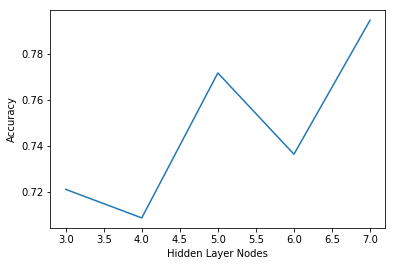

```python
plt.plot(
    neural_params,
    neural_avg_scores)
plt.xlabel("Hidden Layer Nodes")
plt.ylabel("Accuracy")
plt.show()
```

8. Get the hyper-parameter, average accuracy, and standard error for the top-performing model.

```python
neural_top_index = np.argmax(neural_avg_scores)
neural_top_param = neural_params[neural_top_index]
neural_top_score = neural_avg_scores[neural_top_index]
neural_top_error = neural_models.cv_results_["std_test_score"][neural_top_index]
```

9. Inspect the statistics of the top-performing 10 models.

```python
print("Top nnet model is k = {:d} at {:0.2f} +/- {:0.3f} accuracy"
    .format(neural_top_param, neural_top_score, neural_top_error))
```

```
Top nnet model is k = 7 at 0.79 +/- 0.027 accuracy
```

### 8. Evaluate the Models

1. Compare the top three performers numerically.

```python
print("KNN:  {:0.2f} +/- {:0.3f} accuracy"
    .format(knn_top_score, knn_top_error))
print("Tree: {:0.2f} +/- {:0.3f} accuracy"
    .format(tree_top_score, tree_top_error))
print("NNet: {:0.2f} +/- {:0.3f} accuracy"
    .format(neural_top_score, neural_top_error))
```

```
KNN:  0.78 +/- 0.030 accuracy
Tree: 0.81 +/- 0.030 accuracy
NNet: 0.79 +/- 0.027 accuracy
```

2. Compare the top-three performing models visually.

```
(0, 1)
```

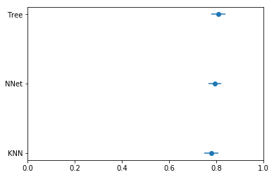

```python
plt.errorbar(
    x = [knn_top_score, tree_top_score, neural_top_score],
    y = ["KNN", "Tree", "NNet"],
    xerr = [knn_top_error, tree_top_error, neural_top_error],
    linestyle = "none",
    marker = "o")
plt.xlim(0, 1)
```

3. Question: Which model would you choose based on this information?

### 9. Test the Final Model

1. Create a final model based on the top-performing algorithm and hyper-parameter.

```python
final_model = DecisionTreeClassifier(
    max_depth = 3)
```

2. Train the final model using the entire training set.

```python
final_model.fit(
    X = X_train,
    y = y_train)
```

```
DecisionTreeClassifier(class_weight=None, criterion='gini', max_depth=3,
            max_features=None, max_leaf_nodes=None,
            min_impurity_decrease=0.0, min_impurity_split=None,
            min_samples_leaf=1, min_samples_split=2,
            min_weight_fraction_leaf=0.0, presort=False, random_state=None,
            splitter='best')
```

6. Predict the labels of the test set using the hold-out test set.

```python
final_predictions = final_model.predict(X_test)
```

7. Get the final prediction accuracy.

```python
final_score = accuracy_score(
    y_true = y_test,
    y_pred = final_predictions)
```

8. Inspect the final prediction accuracy.

```python
print(final_score)
```

```
0.8320610687022901
```

### 10. Deploy the Model

Question to be answered: How likely is it that Jack will survive the Titanic?

1. Create an input feature data frame for Jack.

```python
X_jack = pd.DataFrame(
    columns = ["Class", "Male", "Female", "Age", "Family"],
    data = [[3, 1, 0, 20, 0]])
```

2. Predict if Jack survives.

```python
final_model.predict(X_jack)[0]
```

```
'No'
```

3. What is the liklihood that Jack survives?

```python
final_model.predict_proba(X_jack)[0][1]
```

```
0.13253012048192772
```

4. Question: Would you take that ticket?